# Skriftlig innlevering 4, Oppgave 1 (av 4)

## Oppgave 1 *

Ola vil måle tyngdeakselerasjonen $g$ ved å slippe en stein utfor et høyt loddrett stup. Han holder steinen i ro før han slipper den og lar hans gode venn Petter måle hvor lang tid det tar fra han slipper steinen til den treffer bakken. Han antar at steinen er tilstrekkelig tung til at effekten av luftmotstand er neglisjerbar. Han lar $s$ betegne høyden på stupet og lar $t$ betegne tiden steinen bruker på fallet. Fra fysikkundervisningen på videregående skole husker han at sammenhengen mellom $s$, $g$ og $t$ er gitt som

\begin{align*} s = \frac{1}{2}g t^2. \end{align*}

Dersom han og Petter greier å måle $s$ og $t$ uten feil vil man dermed ha at

\begin{align*} g = \frac{2s}{t^2}. \end{align*}

Ola og Petter går nå på NTNU og vet at det er urealistisk å anta at de greier å måle $s$ og $t$ uten feil. De velger derfor å betrakte verdiene de måler for disse to størrelsene som realisasjoner av stokastiske variabler, og betegner disse stokastiske variablene med henholdsvis $S$ og $T$. Den tilhørende utregnede tyngdeakselerasjonen blir dermed en realisasjon av den stokastiske variabelen

\begin{align*} G = \frac{2S}{T^2}. \end{align*}

Ut fra hvordan målingene av $s$ og $t$ gjøres anser de to gode vennene det naturlig å anta at $S$ og $T$ er uavhengige stokastiske variabler. De lar dessuten $\mu_s$ og $\mu_t$ betegne de sanne (men ukjente) verdiene for henholdsvis $s$ og $t$, og antar at $E[S]=\mu_s$ og $E[T]=\mu_t$. Dessuten innfører de notasjonen $\sigma_s^2=Var[S]$ og $\sigma_t^2=Var[T]$.

Ola og Petter målte $s$ til å være $241.3$ (meter), og $t$ til å være $7.02$ (sekunder).

### Deloppgave a)

Bruk feilforplantningsformelen til å finne formler for tilnærmede verdier for $\mu_g=E[G]$ og $\sigma_g^2=Var[G]$. Du skal oppgi svarene som funksjon av $\mu_s$, $\mu_t$, $\sigma_s^2$ og $\sigma_t^2$.

Ola og Petter er spesielt interessert i usikkerheten $\sigma_g^2$. Ut fra måten de gjør målingene av $s$ og $t$ på finner de det rimelig å sette $\sigma_s=2$ (meter) og $\sigma_t=1$ (sekund). Dessuten approksimerer de ved å sette $\mu_s$ lik den målte verdien for $s$ og $\mu_t$ lik den målte verdien for $t$. Hvilken numeriske verdier får de da for den approksimerte variansen $\sigma_g^2$ og for tilhørende approksimert standardavvik $\sigma_g$?

#### Her er deloppgave a) slutt

Ola og Petter har akkurat lært at stokastisk simulering også kan benyttes for å approksimere $\mu_g$ og $\sigma_g$, og ønsker å bruke dette til å finne alternative approksimasjoner av de to størrelsene.

Når de skal benytte stokastisk simulering er det ikke tilstrekkelig bare å kjenne forventningsverdier og varianser til $S$ og $T$, man må da også anta noe om hvilke fordelinger $S$ og $T$ har. For enkelthets skyld antar de at både $S$ og $T$ er normalfordelte, de setter $\mu_s$ og $\mu_t$ lik tilhørende målte verdier for $s$ og $t$ og bruker de samme verdier for $\sigma_s$ og $\sigma_t$ som i deloppgave a).

### Deloppgave b)

Skriv pythonkode for å simulere $n=10\, 000$ realisasjoner av $G$, og bruk disse til å approksimere $\mu_g$ og $\sigma_g$. Sammenlign med verdiene du fant i deloppgave a) og diskuter.

Tror du $G$ er normalfordelt? For å undersøke dette: Lag et sannsynlighetshistogram av de $n$ genererte verdiene for $G$ og plott deretter (i samme plott som sannsynlighetshistogrammet) sannsynlighetstettheten til en normalfordeling med forventningsverdi og standardavvik lik de approksimerte verdiene for $\mu_g$ og $\sigma_g$.

$$Besvarelse$$

for å finne forventningsverdien til $G$, $\mu_g = E[G]$ og Variansen $\sigma_g^2 = Var[G]$. Brukar vi feilforplantningsformelen. Vi antar at $S$ og $T$ er uavh. og antar at $E[S]=\mu_s$ og $E[T]=\mu_t$. Dessuten innfører de notasjonen $\sigma_s^2=Var[S]$ og $\sigma_t^2=Var[T]$.

Forventnigsverdien $E[G]$ kan tilnærmast direkte fordi det er ein funksjon av uavh. stok. vatiabla ($S$ og $T$). $$ \mu_g = E[G] = E[\frac{2S}{T}] = 2\frac{\mu_s}{\mu_t}=\underline{9.79} $$

For variansen $\sigma_g^2 = Var[G]$ bruka vi feilforplantnigsformelen for funksjon av uavh. stok. var. \begin{align*} \sigma_g^2 &=\left(\frac{\partial G}{\partial S}\right)^2\sigma_s^2 +\left(\frac{\partial G}{\partial T}\right)^2\sigma_t^2\\\\ &= \left(\frac{2}{\mu_t^2}\right)^2\sigma_s^2 + \left(-\frac{4\mu_s}{\mu_t^3}\right)^2\sigma_t^2\\\\ &= 7.79\\\\ \Rightarrow \sigma_g &= \sqrt{\sigma_g^2} = \underline{2.79} \end{align*}

b) kodesnutt

```
Tilnærmet mu_g basert på simulering: 10.465651310900377
Tilnærmet sigma_g basert på simulering: 3.4219599248382755
```

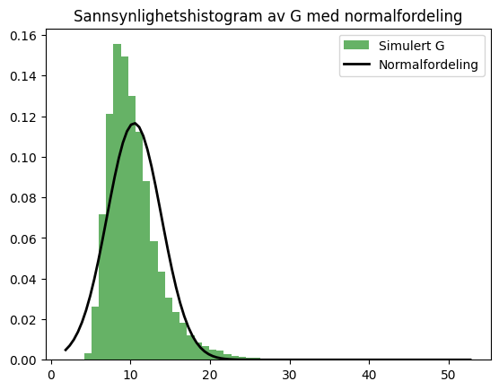

```python
# Her kan du skrive pythonkoden din
import numpy as np
import matplotlib.pyplot as plt
import scipy.stats as stats

# Definerer antall simuleringer og parametere
n = 10000
mu_s = 241.3  # målt verdi for s
mu_t = 7.02  # målt verdi for t
sigma_s = 2  # standardavvik for s
sigma_t = 1  # standardavvik for t

# Simulerer S og T basert på antatte normalfordelinger
S_sim = np.random.normal(mu_s, sigma_s, n)
T_sim = np.random.normal(mu_t, sigma_t, n)

# Beregner G basert på simulerte S og T
G_sim = 2 * S_sim / T_sim**2

# Beregner tilnærmede verdier for mu_g og sigma_g basert på simuleringene
mu_g_sim = np.mean(G_sim)
sigma_g_sim = np.std(G_sim)

# Skriver ut tilnærmede verdier
print(f"Tilnærmet mu_g basert på simulering: {mu_g_sim}")
print(f"Tilnærmet sigma_g basert på simulering: {sigma_g_sim}")

# Plotter sannsynlighetshistogram for G
plt.hist(G_sim, bins=50, density=True, alpha=0.6, color='g', label='Simulert G')

# Plotter sannsynlighetstettheten for en normalfordeling med tilnærmet mu_g og sigma_g
xmin, xmax = plt.xlim()
x = np.linspace(xmin, xmax, 100)
p = stats.norm.pdf(x, mu_g_sim, sigma_g_sim)
plt.plot(x, p, 'k', linewidth=2, label='Normalfordeling')

plt.title("Sannsynlighetshistogram av G med normalfordeling")
plt.legend()
plt.show()
```

## Oppgave 2 *

Vi betrakter en skålvekt for veiing av prøver. Prøven med vekt $\mu$ plasseres på en av skålene og lodd plasseres på den andre skålen til vektens arm er tilnærmet horisontal. Den kjente vekten av loddene er da tilnærmet lik prøvens vekt. Vi antar at den målte vekt er normalfordelt med forventningsverdi $\mu$ og varians $\sigma^2$ og at resultatene av forskjellige målinger er uavhengige.

### Deloppgave a)

Anta i denne deloppgaven at man gjør to veiinger av en prøve hvor $\mu=10$ gram og $\sigma=0.2$ gram. La $X$ og $Y$ være målt vekt i de to veiingene.

Hva er sannsynligheten for at gjennomsnittlig målt vekt er større enn $10.2$ gram?

Hva er sannsynligheten for at differansen mellom de to målte vektene er større enn $0.4$ gram?

#### Her er deloppgave a) slutt.

Det er kommet inn to prøver som begge skal veies, prøve A og prøve B. La $\mu_A$ og $\mu_B$ betegne de sanne vektene av prøvene. Det er foreslått å estimere vektene av prøve A og B på to forskjellige måter:

Alternativ 1: Vei først prøve A fem ganger, og la $X_1,X_2,X_3,X_4,X_5$ betegne de målte vektene. Vei deretter prøve B fem ganger, og la $Y_1,Y_2,Y_3,Y_4,Y_5$ betegne de målte vektene. Bruk så følgende estimatorer for $\mu_A$ og $\mu_B$,

\begin{align*} \hat{\mu}_A = \overline{X} = \frac{1}{5}\sum_{i=1}^5 X_i \,\,\,\,\,\,\text{og}\,\,\,\,\,\,\hat{\mu}_B = \overline{Y} = \frac{1}{5}\sum_{i=1}^5 Y_i. \end{align*}

Alternativ 2: Vei først fem ganger summen av vekten på prøve A og B ved å plassere begge prøvene på samme vektskål og la $U_1,U_2,U_3,U_4,U_5$ betegne de målte vektene. Vei deretter fem ganger differansen mellom vektene på prøve A og prøve B, dvs A-B, ved å plassere prøvene på hver sin vektskål, og la $V_1,V_2,V_3,V_4,V_5$ betegne de målte differansene. Bruk så følgende estimatorer for $\mu_A$ og $\mu_B$,

\begin{align*} \tilde{\mu}_A = \frac{1}{2}\left(\overline{U}+\overline{V}\right)\,\,\,\,\,\,\text{og}\,\,\,\,\,\,\tilde{\mu}_B=\frac{1}{2}\left(\overline{U}-\overline{V}\right), \end{align*}

der $\overline{U}=\frac 1 5 \sum_{i=1}^5U_i$ og $\overline{V}=\frac 1 5 \sum_{i=1}^5 V_i$.

### Deloppgave b)

Finn forventningsverdi og varians for de fire estimatorene $\hat{\mu}_A$, $\hat{\mu}_B$, $\tilde{\mu}_A$ og $\tilde{\mu}_B$.

*Merk: hver gang man leser av vekten med denne skålvekten har vi samme usikkerhet, $\sigma$. Dvs. hver måling har samme usikkerhet.*

Hvilken av de to alternative fremgangsmåtene for å estimere $\mu_A$ og $\mu_B$ vil du foretrekke? Gi en begrunnelse for svaret.

$$Besvarelse$$

La gjenomsnittet av dei to vektene ver $Z=\frac{X+Y}{2}$ siden begge målingane har samme forventnigsverdi har vi at $\mu_Z = E[Y] = \mu$ og fordi at $X$ og $Y$ er uavh. med samme forventningsverdi og varians har vi at $\sigma_z^2 = \frac{\sigma}{2}$

For å finne sansynligheten for at dei to målte vektane er større enn $10.2g$ skal vi bruke $Z$-transformasjon til å løyse for $P(Z>10.2) $ $$ P(Z>10.2) = P(Z\leq -\frac{\overline{X}-\mu_z}{\sigma_Z}) = P(z\leq -1.41) = \underline{0.0793} $$

for å finne differasenen definerer vi $D=X-Y$. då blir $\mu_d = E[D] = \mu - \mu = 0$ og $\sigma_d^2 = Var[D] = 2\sigma^2$ og bruker så Z transformasjon for å løyse for $P(|D|>0.4)$ \begin{align*} P(|D|>0.4) &= 2P(D>0.4) = 2P\left(D>\frac{0.4-0}{0.2\sqrt{2}}\right) \\\\ &=2P(D\leq -1.41) = \underline{0.1586} \end{align*}

b)

- Aletrantiv 1)

Sidane $X_i$ og $Y_i$ er uavhengige målingar av $\hat{\mu}_A$ og $\hat{\mu}_B$ respektivt, og forventningsverdien av kvar måling er lik den sanne verdien, får vi: \begin{align*} E[\hat{\mu}_A] = E[\overline{X}] = \mu_A \\ E[\hat{\mu}_B] = E[\overline{Y}] = \mu_B \\ \end{align*} og for variansen \begin{align*} Var[\hat{\mu}_A] = \frac{1}{5^2}\sum_{i=1}^5 Var[X_i] = \frac{1}{5}\sigma^2\\\\ Var[\hat{\mu}_B] = \frac{1}{5^2}\sum_{i=1}^5 Var[Y_i] = \frac{1}{5}\sigma^2 \end{align*}

- Alternativ 2)

\begin{align*} E[\overline{U}] = \mu_A + \mu_B\\ E[\overline{V}] = \mu_A - \mu_B\\\\ E[\tilde{\mu}_A] = \frac{1}{2}(E[\overline{U}] + E[\overline{V}])= \mu_A\\ E[\tilde{\mu}_B] = \frac{1}{2}(E[\overline{U}] - E[\overline{V}])= \mu_B\\ \end{align*}

Så begge alternativa er forventningsrett. då er det variansen som bestemmer

\begin{align*} Var[\overline{U}] &= \frac{1}{5}\sigma^2\\ Var[\overline{V}] &= \frac{1}{5}\sigma^2\\\\ Var[\tilde{\mu}_A] &= Var\left[\frac{1}{2}\left(\overline{U}+\overline{V}\right)\right]\\ &= \frac{1}{4}(Var[\overline{U}] + Var[\overline{V}] )\\ &= \frac{1}{4}\frac{2\sigma^2}{5} = \frac{\sigma^2}{10}\\\\ Var[\tilde{\mu}_B] &= Var\left[\frac{1}{2}\left(\overline{U}-\overline{V}\right)\right]\\ &= \frac{1}{4}(Var[\overline{U}] + Var[\overline{V}] )\\ &= \frac{1}{4}\frac{2\sigma^2}{5} = \frac{\sigma^2}{10}\\\\ \end{align*}

Aletnativ 2 gir lavare varians. Altså vil alternativ 2 vere ein meir presis estimator.

## Oppgave 3 *

Det vurderes å utbedre en lite trafikkert, men farlig veistrekning i Trondheimsområdet. I den sammenheng blir du bedt om å analysere hvor mye trafikk det er på veien. La $X$ være antall biler som passerer et bestemt punkt på veistrekningen fra kl 16:00 til kl 18:00 på en tilfeldig valgt hverdag. Vi antar at $X$ er poissonfordelt med parameter $\lambda$, dvs

\begin{align*} f(x) = \frac{\lambda^x}{x!}e^{-\lambda},\,\,\,,x=0,1,2,\ldots \end{align*}

Verdien til parameteren $\lambda$ er ukjent, så for å kunne estimere denne verdien oberverer vi antall passerende biler fra kl 16:00 til 18:00 på $n$ tilfeldig valgte hverdager, og lar $X_1,X_2,\ldots,X_n$ være antall biler som passerte på disse $n$ dagene.Vi antar at observasjonene er uavhengige og identisk fordelt med samme poissonfordeling som beskrevet over.

### Deloppgave a)

Utled sannsynlighetsmaksimeringsestimatoren (SME) for $\lambda$, $\hat{\lambda}$, basert på $X_1,X_2,\ldots,X_n$.

Er $\hat{\lambda}$ forventningsrett? Begrunn svaret.

Finn variansen til $\hat{\lambda}$.

#### Her er deloppgave a) slutt.

Kommunen ønsker å samle inn mer data om hvor trafikkert veien er. Derfor registreres det også hvor mange biler som passerer på veien fra kl 18:00 til kl 20:00 på $m$ tilfeldig valgte hverdager, og vi lar $Y_1,Y_2,\ldots,Y_m$ være antall biler som da passerer. Vi antar at disse observasjonene er uavhengige og identisk poissonfordelte med parameter $\lambda/2$, altså halv intensitet i forhold til fra kl 16:00 til kl 18:00. Vi antar også uavhengighet mellom $Y_1,Y_2,\ldots,Y_m$ og $X_1,X_2,\ldots,X_n$.

Som estimator for $\lambda$ basert på $X_1,X_2,\ldots,X_n$ og $Y_1,Y_2,\ldots,Y_m$ er det foreslått

\begin{align*} \tilde{\lambda} = \alpha \overline{X} + \beta \overline{Y}, \end{align*}

der $\alpha,\beta\in\mathbb{R}$ er to konstanter som skal velges, og $\overline{X}=\frac 1 n \sum_{i=1}^nX_i$ og $\overline{Y}=\frac 1 m \sum_{i=1}^m Y_i$.

### Deloppgave b)

Bestem konstantene $\alpha$ og $\beta$ slik at estimatoren $\tilde{\lambda}$ blir best mulig. Svaret skal angis som funksjoner av $n$ og $m$.

### Deloppgave c)

Til slutt i denne oppgaven skal du bruke stokastisk simulering til undersøke fordelingen til estimatoren $\tilde{\lambda}$ når verdiene til konstantene $\alpha$ og $\beta$ velges lik de optimale verdiene du fant i deloppgave b). La $n=42$ og $m=35$, og sett $\lambda=12$.

Skriv python-kode som $r=1000$ ganger simulerer verdier for $X_1,X_2,\ldots,X_n$ og $Y_1,Y_2,\ldots,Y_m$ og regner ut resulterende verdi for $\tilde{\lambda}$. Lag et sannsynlighetshistogram for de $r$ simulerte verdiene for $\tilde{\lambda}$. Bruk for eksempel "bins=25" som argument i pythonfunksjonen "plt.hist".

Greier du ut fra sannsynlighetshistogrammet å vurdere om $\tilde{\lambda}$ er normalfordelt? Hvor sikker er du i din vurdering?

Lag et normalfordelingsplott (qq-plot) basert på de $r$ simulerte verdiene for $\tilde{\lambda}$. Ser $\tilde{\lambda}$ ut til å være normalfordelt? *Hint: Du kan bruke pythonfunksjonen "qqplot" i modulen statsmodels for å generere et qq-plot. Under ser du hvordan du kan laste inn modulen statsmodel og hvordan du kan kalle funksjonen qqplot. Her er det antatt at dine simulerte verdier for $\tilde{\lambda}$ ligger i en vektor med navn "lambdatilde".*

Kan du gi en teoretisk begrunnelse for at $\hat{\lambda}$ er (i hvert fall tilnærmet) normalfordelt?

- A)

SME for $\lambda$ \begin{align*} L(\lambda) &= \prod_{i=1}^n \frac{\lambda^{x_i}}{x_i!}e^{-\lambda}\\\\ &= \lambda^{\sum_{i=1}^n x_i}e^{-n\lambda}\prod_{i=1}^n \frac{\lambda^{x_i}}{x_i!} \end{align*} For å maksimere sansynlightesestimatoren tar vi logaritmen av $L(\lambda)$ og deriverer for så å sette lik 0 for å finne toppunnkt, og bruker notasjonen $\mathcal{l}(\lambda) = ln(L(\lambda))$ \begin{align*} \mathcal{l}(\lambda) &= \sum_{i=1}^n (x_i) ln(\lambda)-n\lambda + ln\left(\prod_{i=1}^n\ \frac{\lambda^{x_i}}{x_i!}\right) \\\\ \mathcal{l}'(\lambda) &= \frac{\sum_{i=1}^nx_i}{\lambda} -n + 0\\\\ &\Rightarrow \lambda = \frac{\sum_{i=1}^nx_i}{n} \end{align*} Så SME for $\lambda$ blir $\hat{\lambda} = \frac{\sum_{i=1}^nx_i}{n}$

For å sjekke om $\hat{\lambda}$ er forventnigsrett skal vi finne forventningsverdien til $\hat{\lambda}$

\begin{align*} E[\hat{\lambda}] = E\left[\frac{\sum_{i=1}^nx_i}{n}\right] = \frac{1}{n}nE[x_i] = E[x_i] = \lambda \end{align*} Forventnigsverdien blir $\lambda$ så då er den forventnigsrett

Variansen til $\hat{\lambda}$. i poissonfordeling er $Var(X)=\mu$

\begin{align*} Var[\hat{\lambda}] = Var\left[\frac{\sum_{i=1}^nx_i}{n}\right] = \frac{1}{n^2}nVar[x_i] = \frac{1}{n}Var[x_i] = \frac{\lambda}{n} \end{align*}

- b)

For å finne eit utrykk for konstantane $\alpha$ og $\beta$ som gir ein best mulig estimator $\tilde{\lambda}$ må vi løyse følgande likning: \begin{align*} \tilde{\lambda} = \alpha\overline{X} + \beta\overline{Y} = \text{best mulig}\\\\ \end{align*}

vi har at $E[\overline{X}] = \lambda$ og $E[\overline{Y}] = \frac{1}{2}\lambda$ og forventngisverdien til $\tilde{\lambda}$ må då vere \begin{align*} E[\tilde{\lambda}] = \alpha E[\overline{X}] + \beta E[\overline{Y}] = \lambda(\alpha + \frac{1}{2}\beta)\\ \end{align*} Dersom $\tilde{\lambda}$ skal vere forventnigsrett må $E[\tilde{\lambda}] = \lambda$ \begin{align*} \lambda = \lambda(\alpha + \frac{1}{2}\beta)\\ 1 = \alpha + \frac{1}{2}\beta\\ \alpha + \frac{1}{2}\beta-1 = 0 \end{align*}

No løyser vi for Varians for å få enda ein liknig og så bruker vi Lagrange-regel for å minimere Variansen

Først berekner vi for $Var[\overline{X}] = \frac{\lambda}{n}$ og $Var[\overline{Y}] = \frac{\lambda}{2m}$ \begin{align*} Var[\tilde{\lambda}] &=\alpha^2 Var[\overline{X}] + \beta^2 Var[\overline{Y}]\\ &= \alpha^2\frac{\lambda}{n} + \beta^2 \frac{\lambda}{2m} \end{align*}

No kan vi bruke Lagrange-multiplikator med å innføre $L(\alpha,\beta,\gamma) = \alpha^2\frac{\lambda}{n} + \beta^2 \frac{\lambda}{2m} - \gamma(\alpha + \frac{1}{2}\beta-1)$. for så å partiellderivere $L(\alpha,\beta,\gamma)$ og sette opp eir system av likninga.

\begin{align} L_{\alpha} &= 2\alpha\frac{\lambda}{n} - \gamma = 0\\ L_{\beta} &= \beta\frac{\lambda}{m} - \frac{1}{2}\gamma = 0\\ L_{\gamma} &= \alpha + \beta\frac{1}{2}-1 = 0 \\ \end{align}

Siden $\lambda$ er uinteressant kan vi la $\lambda$ "gå inn i" $\gamma$ kan vi gjere det enklare for oss

\begin{align} L_{\alpha} &= 2\alpha\frac{1}{n} - \gamma = 0\\ L_{\beta} &= \beta\frac{1}{m} - \frac{1}{2}\gamma = 0\\ L_{\gamma} &= \alpha + \beta\frac{1}{2}-1 = 0 \\ \end{align}

så dryssa vi på litt algebra

\begin{align*} \gamma &= \alpha\frac{2}{n} \ \tag{1}\\\\ \beta &= \frac{m}{2}\alpha\frac{2}{n} = \alpha\frac{m}{n} \tag{2}\\ \alpha &= \beta\frac{n}{m}\\\\ \beta\left(\frac{n}{m}+ \frac{1}{2} \right) &= 1 \tag{3}\\ \beta &= \frac{2m}{2n+m}\\\\ \alpha &= \frac{2m}{2n+m}\frac{n}{m}\tag{2}\\ \alpha &= \frac{2n}{2n+m} \end{align*}

$\beta = \frac{2m}{2n+m} \ , \ \alpha = \frac{2n}{2n+m}$

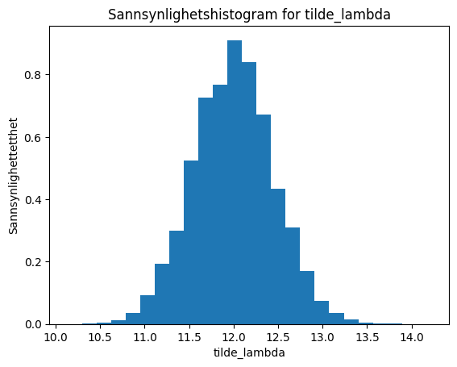

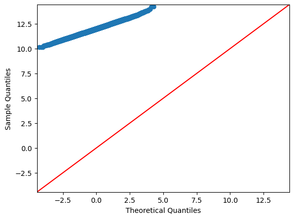

```python
#Her kan du skrive kode for å simulere verdier og lage sannsynlighetshistogram
import statsmodels.api as sm
import numpy as np
import matplotlib.pyplot as plt

# Definerer parameterverdier
n = 42
m = 35
lambda_real = 12
r = 100000

# Optimal verdi for alpha og beta basert på tidligere deloppgave
alpha_opt = 2*n / (2*n + m)
beta_opt = 2*m / (2*n + m)

# Initialiserer en tom liste for å lagre de simulerte verdiene av tilde_lambda
tilde_lambda_values = []

# Utfører r stokastiske simuleringer
for _ in range(r):
    # Simulerer X og Y verdiene
    X_values = np.random.poisson(lam=lambda_real, size=n)
    Y_values = np.random.poisson(lam=lambda_real/2, size=m)

    # Beregner estimatorene overline_X og overline_Y
    overline_X = np.mean(X_values)
    overline_Y = np.mean(Y_values)

    # Beregner estimatoren tilde_lambda basert på de simulerte verdiene
    tilde_lambda = alpha_opt * overline_X + beta_opt * overline_Y
    tilde_lambda_values.append(tilde_lambda)

# Plotter et sannsynlighetshistogram for de r simulerte verdiene for tilde_lambda
plt.hist(tilde_lambda_values, bins=25, density=True)
plt.title('Sannsynlighetshistogram for tilde_lambda')
plt.xlabel('tilde_lambda')
plt.ylabel('Sannsynlighettetthet')
plt.show()


# Generer qq-plot
sm.qqplot(np.array(tilde_lambda_values), line ='45')
plt.show()
```

Den er normalfordelt, sikkerhetsnivå type beinsikker

## Oppgave 4

En kjemistudent har fått i oppgave å estimere konsentrasjonen av koffein i Coca Cola. Han undersøker $n$ prøver, hver med nøyaktig samme volum, $1.0$ dl, Coca Cola. For hver prøve måles antall mg koffein i prøven.

La $x_i$ betegne målt koffeininnhold, i mg, for prøve nr. $i=1,2,...,n$. Vi antar at $X_1, X_2,...,X_n$ er uavhengige og normalfordelte med (ukjent) forventningsverdi $\mu$ og kjent standardavvik $\sigma=0.19$, og at målingene $x_1,x_2,...,x_n$ er er realisasjoner av de stokastiske variablene $X_1, X_2,...,X_n$.

### Deloppgave a)

Gi en kort forklaring av de fysiske tolkningene av parameterne $\mu$ og $\sigma$ basert på den informasjonen du har fått.

### Deloppgave b)

Med utgangspunkt i at det skal gjøres $n$ målinger, utled uttrykket for et $(1-\alpha)\cdot 100\%$-konfidensintervall for $\mu$. Forklar hvorfor nedre og øvre grense vil variere hver gang forsøket gjentas.

Kjemistudenten har gjort $n=12$ målinger og rapporterer at det empiriske gjennomsnittet er $\bar x= \sum^n_{i=1} x_i = 8.2$. Regn ut et $95\%$ konfidensintervall for $\mu$.

#### Her er deloppgave b) slutt.

Kjemistudenten er ikke fornøyd med bredden på konfidensintervallet. Han vurderer derfor å gjenta eksperimentet med et nytt antall målinger, $n$.

### Deloppgave c)

Bestem den minste gyldige verdien for $n$ slik at bredden på $95\%$-konfidensintervallet blir høyst $0.1$.

$$Besvarelse$$

a)

$\mu$ (forventningsverdi) representerer den gjennomsnittlege konsentrasjonen av koffein (i mg) i ein 1.0 dl Coca Cola-prøve. Det er eit mål på den "sanne" koffeinkonsentrasjonen som vi ønskjer å estimere gjennom eksperimentet. Sidan $\mu$ er ukjent, bruker vi prøvedata til å gjere estimat om denne verdien.

$\sigma$ (standardavvik) er det kjente standardavviket for koffeinkonsentrasjonen i prøvene, som er $0.19$ mg. Dette målet fortel oss kor mykje individuelle målingar av koffeininnhaldet ($x_i$) typisk avviker frå den gjennomsnittlege konsentrasjonen $\mu$. Eit lavt standardavvik indikerer at målingane ligg tett rundt gjennomsnittet, medan eit høgt standardavvik tyder på større spreiing i målingane.

b)

Forsøka er normalfordeltn $N(\mu,\ \sigma^2)$, så estimator for $\mu$ blir $\hat{\mu} = \overline{X} = \frac{1}{n}\sum_{i=1}^nX_i$ og $\overline{X}$ blir då normalfordelt $\overline{X} \ \sim \ N(\mu,\frac{\sigma^2}{n})$ det kan vi standarisere slik at $\frac{\overline{X}-\mu}{\sqrt{\frac{\sigma^2}{n}}}\ \sim \ N(0,1)$

Det gir oss uttrykket $P(-Z_{\frac{\alpha}{2}}\leq \frac{\overline{X}-\mu}{\sqrt{\frac{\sigma^2}{n}}} \leq Z_{\frac{\alpha}{2}}) = 1-\alpha$

no er det kun $\mu$ som er ukjent, og vi må løyse dei to ulikheitane med hensyn på $\mu$

\begin{align*} -Z_{\frac{\alpha}{2}} &\leq \frac{\overline{X}-\mu}{\sqrt{\frac{\sigma^2}{n}}} \tag{1}\\ -Z_{\frac{\alpha}{2}}\frac{\sigma}{\sqrt{n}} &\leq \overline{X}-\mu\\ \mu &\leq \overline{X} + Z_{\frac{\alpha}{2}}\frac{\sigma}{\sqrt{n}}\\\\ \frac{\overline{X}-\mu}{\sqrt{\frac{\sigma^2}{n}}} &\leq Z_{\frac{\alpha}{2}} \tag{2}\\ \mu &\geq \overline{X} + Z_{\frac{\alpha}{2}}\frac{\sigma}{\sqrt{n}} \end{align*}

Kofidensintervallet blir då \begin{align*} \left[\overline{X} - Z_{\frac{\alpha}{2}}\frac{\sigma}{\sqrt{n}} \ , \ \overline{X} + Z_{\frac{\alpha}{2}}\frac{\sigma}{\sqrt{n}}\right] = [\theta_L, \theta_U] \end{align*}

Med $95\%$ konfidensintervall finner vi $Z_{\frac{\alpha}{2}}$ i tabell for $\frac{\alpha}{2} \Rightarrow Z_{\frac{\alpha}{2}} = 1.960$

\begin{align*} &\left[8.2 - 1.960\frac{0.19}{\sqrt{12}} \ , \ 8.2 + 1.960\frac{0.19}{\sqrt{12}}\right]\\\\ &= \left[8.092 \ , \ 8.308 \right]\\ \end{align*}

Fordi forsøket er avhengig av kva $\overline{X}$ er, vil øvre og nøedre grense flytte seg om dette "arbeidspunktet".

c)

Bredden til intervallet er gitt ved : $\theta_U-\theta_L = 2Z_{\frac{\alpha}{2}}\frac{\sigma}{\sqrt{n}}$. visst vi vil at bredden skal blir $0.1$ må vi løyse for

\begin{align*} 0.1 &= 2Z_{\frac{\alpha}{2}}\frac{\sigma}{\sqrt{n}}\\ \sqrt{n} &= 2Z_{\frac{\alpha}{2}}\frac{\sigma}{0.1}\\ n &= 4Z_{\frac{\alpha}{2}}^2\frac{\sigma^2}{0.1^2}\\ n &= 4\cdot 1.960^2\frac{0.19^2}{0.1^2} \\ n &\approx 55,47 \end{align*} sidan n må vere eit heiltall må vi runde opp til nærmaste heiltall. $$n = 56$$

## Oppgave 5

Det er vanlig at gjennomsnittstemperaturen i mars er lavere enn gjennomsnittstemperaturen i april. I 2012 var det mange steder i Norge kaldere i april enn i mars.

Vi lar $X$ være gjennomsnittstemperatur i mars og $Y$ gjennomsnitsstemperatur i april ved Værnes et gitt år, begge målt i $^\circ C$. Anta at $X$ er normalfordelt med ukjent forventningsverdi $\mu_m$ og varians $\sigma^2$, og at $Y$ er normalfordelt med ukjent forventningsverdi $\mu_a$ og varians $\sigma^2$.

### Deloppgave a)

Anta at vi har data for verdier av $X$ og $Y$ fra $n=12$ ulike år. Du kan anta at dette er et tilfeldig utvalg. Forklar hvordan du kan grafisk undersøke om antakelse om normalfordeling holder. Hvordan kan du undersøke grafisk om $X$ og $Y$ er uavhengige?

Du skal nå gjennomføre den grafiske undersøkelsen med den gitte dataen gitt under. Begrunn om normalantakelsen holder, og om det virker som $X$ og $Y$ er uavhengige. \begin{array}{c|c|c|c|c|c|c|c|c|c|c|c} & 2001 & 2002 & 2003 & 2004 & 2005 & 2006 & 2007 & 2008 & 2009 & 2010 & 2011 & 2012\\ \hline x & -2.5 & 0.5 & 3.3 & 2.6 & -0.7 & -4.6 & 3.3 & 0.8 & 1.9 & -0.5 & 1.2 & 3.8 \\ y & 4.1 & 7.2 & 5.0 & 7.9 & 5.8 & 4.9 & 5.0 & 5.9 & 6.9 & 4.8 & 6.7 & 3.2 \end{array}

$$Besvarelse$$

For å undersøke antakelsen om normalfordeling grafisk, kan vi bruke et histogram eller en Q-Q-plot (kvantil-kvantil-plot). Et histogram vil vise fordelingen av dataene og kan gi en indikasjon på om de ser ut til å være normalfordelt ved å sammenligne formen med en normalfordelingskurve. En Q-Q-plot sammenligner de sorterte verdiene fra datasettet med de forventede verdiene fra en normalfordeling. Hvis punktene i en Q-Q-plot følger en rett linje, indikerer det at datasettet er omtrentlig normalfordelt.

For å undersøke om $X$ og $Y$ er uavhengige grafisk, kan vi bruke et spredningsplott (scatter plot). I et spredningsplott vil vi se etter mønstre eller en tydelig korrelasjon mellom $X$ og $Y$. Hvis det ikke er noen tydelig trend eller mønster, og punktene ser ut til å være tilfeldig fordelt, kan det indikere at $X$ og $Y$ er uavhengige.

```python
import numpy as np
import matplotlib.pyplot as plt

x = np.array([-2.5, 0.5, 3.3, 2.6, -0.7, -4.6, 3.3, 0.8, 1.9,-0.5, 1.2, 3.8])
y = np.array([4.1, 7.2, 5.0, 7.9, 5.8, 4.9, 5.0, 5.9, 6.9, 4.8, 6.7, 3.2])


#Normalantakelse


#Uavhengighet mellom X og Y

import scipy as sp
sp.stats.binomial()
```

[output not shown]

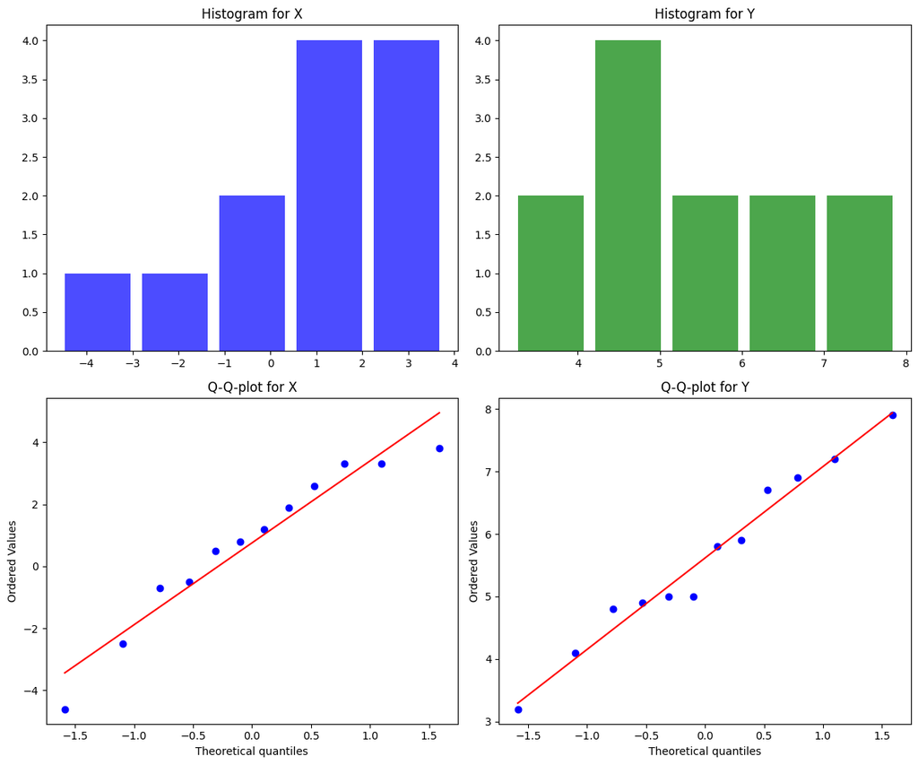

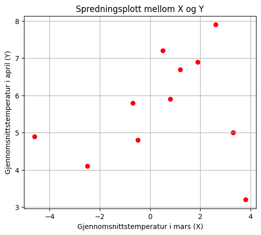

```python
import numpy as np
import matplotlib.pyplot as plt
import scipy.stats as stats

x = np.array([-2.5, 0.5, 3.3, 2.6, -0.7, -4.6, 3.3, 0.8, 1.9,-0.5, 1.2, 3.8])
y = np.array([4.1, 7.2, 5.0, 7.9, 5.8, 4.9, 5.0, 5.9, 6.9, 4.8, 6.7, 3.2])

# Normalantakelse: Histogram og Q-Q-plot for X og Y
fig, axs = plt.subplots(2, 2, figsize=(12, 10))

# Histogram for X
axs[0, 0].hist(x, bins='auto', color='blue', alpha=0.7, rwidth=0.85)
axs[0, 0].set_title('Histogram for X')

# Histogram for Y
axs[0, 1].hist(y, bins='auto', color='green', alpha=0.7, rwidth=0.85)
axs[0, 1].set_title('Histogram for Y')

# Q-Q-plot for X
stats.probplot(x, dist="norm", plot=axs[1, 0])
axs[1, 0].set_title('Q-Q-plot for X')

# Q-Q-plot for Y
stats.probplot(y, dist="norm", plot=axs[1, 1])
axs[1, 1].set_title('Q-Q-plot for Y')

plt.tight_layout()
plt.show()

# Uavhengighet mellom X og Y: Spredningsplott
plt.figure(figsize=(6, 5))
plt.scatter(x, y, color='red')
plt.title('Spredningsplott mellom X og Y')
plt.xlabel('Gjennomsnittstemperatur i mars (X)')
plt.ylabel('Gjennomsnittstemperatur i april (Y)')
plt.grid(True)
plt.show()
```

Basert på den grafiske undersøkelsen:

Q-Q-plottene for både $X$ og $Y$ viser at punktene stort sett følger en rett linje, noe som indikerer at dataene for $X$ og $Y$ er omtrentlig normalfordelt. Dette støtter normalantakelsen for både $X$ og $Y$.

Spredningsplottet mellom $X$ og $Y$ viser ingen tydelig trend eller mønster som indikerer en sterk korrelasjon mellom gjennomsnittstemperaturen i mars og april. Punktenes fordeling ser relativt spredt ut, noe som kan tyde på at $X$ og $Y$ er uavhengige av hverandre. Likevel, uten en statistisk korrelasjonstest er det vanskelig å konkludere med full sikkerhet.

Samlet sett tyder den grafiske undersøkelsen på at normalantakelsen holder for både $X$ og $Y$, og det er ingen umiddelbare bevis for at $X$ og $Y$ ikke er uavhengige basert på spredningsplottet. Imidlertid er det viktig å merke seg at grafiske metoder gir indikasjoner snarere enn definitive bevis, og videre statistiske analyser kan være nødvendige for å støtte disse observasjonene.

### Deloppgave b)

Anta at temperaturene fra mars er uavhengige fra et år til et annet. Finn et $99\%$-konfidensintervall for forventet gjennomsnittstemperatur i mars.

$$Besvarelse$$

kjenner ikkje $\sigma$, så vi bruker $S$. når vi bytter $\sigma$ med $S$ følger vi student t-fordeling, som har ein mindre friheitsgrad.

Vi har kartlagt at $X$ er normalfordelt. Når vi har normalfordeling vil vi standarisere, men sidan $\sigma$ er ukjent bytter vi $Z$ med $T$.

\begin{align*} T &= \frac{\overline{X}-\mu}{\sqrt{\frac{s^2}{n}}}\\\\ \overline{X} &= \frac{1}{n}\sum_{i=1}^nX_i\\\\ S^2 &= \frac{1}{n-1}\sum_{i=1}^n(X_i-\overline{X})^2 \end{align*}

Utleding av formelen for konfidensintervallet for t-fordeling.

Bruker vi Teoremet som sier: La $X_1,X_2,...,X_n$ vere tilfeldig utval fra $N(\mu,\sigma^2)$-populasjonen. Då er $$V=\sum_{i=1}^n\left(\frac{X_i-\overline{X}}{\sigma}\right)^2 \sim \mathcal{X}_{n-1}^2$$ , og dessuten er $\overline{X}$ og $V$ uavh. stok. var.

merk at $V = \frac{(n-1)S^2}{\sigma^2}$. Ved å benytte dette får vi at \begin{align*} T &= \frac{\overline{X}-\mu}{\sqrt{\frac{s^2}{n}}} = \frac{\frac{\overline{X}-\mu}{\sqrt{\frac{\sigma^2}{n}}}}{\sqrt{\frac{\frac{(n-1)s^2}{\sigma^2}}{n-1}}} = \frac{Z}{\sqrt{\frac{V}{n-1}}} \sim t_{n-1} \\\\ \end{align*}

Altså er $T = t_{\frac{\alpha}{2}, n-1}$ student t-fordelt med $\nu = n-1$ (frihetsgrader). Så då kan vi bare løyse utrykket med hensyn på $\mu$.

\begin{align*} T &= \frac{\overline{X}-\mu}{\sqrt{\frac{s^2}{n}}}\\\\ T\frac{s}{\sqrt{n}} &= \overline{X}-\mu\\\\ \mu &= \overline{X} - t_{\frac{\alpha}{2}, n-1}\frac{s}{\sqrt{n}} \end{align*}

Det gir intervallet \begin{align*} \left[\overline{X} - t_{\frac{\alpha}{2}, n-1}\frac{s}{\sqrt{n}} \ , \ \overline{X} + t_{\frac{\alpha}{2}, n-1}\frac{s}{\sqrt{n}}\right] \end{align*}

Vi kan finne $t_{\frac{\alpha}{2}, n-1}$ i tabell : $\frac{\alpha}{2} = 0.005, n-1 = 11 \Rightarrow t_{\frac{\alpha}{2}, n-1} = 3.106$ og $s = \sqrt{\frac{1}{n-1}\sum_{i=1}^n(X_i-\overline{X})^2} =\sqrt{\frac{1}{n-1}}\sum_{i=1}^n(X_i-\overline{X})$ å berekne leddet $\sum_{i=1}^n(X_i-\overline{X})$ har eg brukt python til, fordi eg er lat. og fikk at $s = 2.526$ og $\overline{X} = 0.758$

Så intervallet blir då $$(0.758\pm3.106\frac{2.526}{12})^\circ C = [-1.506 \ , \ 3.023]^\circ C$$

```python
# Beregninger og utskrift
n = len(x)  # Antall observasjoner
x_snitt = np.mean(x)  # Gjennomsnitt av X
s_x = np.std(x, ddof=1)  # Standardavviket til X med Bessel's korreksjon
alpha = 0.01  # For et 99% konfidensnivå
t_critical_x = stats.t.ppf(1 - alpha / 2, n - 1)  # Kritisk t-verdi for X
margin_of_error = t_critical_x * (s_x / np.sqrt(n))  # Margin of error
ci_lower = x_snitt - margin_of_error  # Nedre grense for konfidensintervallet
ci_upper = x_snitt + margin_of_error  # Øvre grense for konfidensintervallet

# Utskrift av resultater
print(f"Gjennomsnittstemperatur i mars (x_snitt): {x_snitt:.3f}°C")
print(f"Standardavviket til X (s_x): {s_x:.3f}")
print(f"Kritisk t-verdi for X: {t_critical_x:.3f}")
print(f"99% konfidensintervall for gjennomsnittstemperaturen i mars: ({ci_lower:.3f}, {ci_upper:.3f})°C")
```

[output not shown]

## Fasit:

- Oppgave 1a: $\sigma_g^2\approx 7.791$
- Oppgave 2a: $0.0793$, $0.1586$
- Oppgave 2b: $E[\hat{\mu}_A]=\mu_A$, $E[\hat{\mu}_B]=\mu_B$, $Var[\hat{\mu}_A]=Var[\hat{\mu}_B]=\frac{\sigma^2}{5}$, $E[\tilde{\mu}_A]=\mu_A$, $E[\tilde{\mu}_B]=\mu_B$, $Var[\tilde{\mu}_A]=Var[\tilde{\mu}_B]=\frac{\sigma^2}{10}$
- Oppgave 3a: $\hat{\lambda}$ er forventningsrett, $Var[\hat{\lambda}]=\frac{\lambda}{n}$
- Oppgave 3b: $\alpha=\frac{2n}{2n+m}$, $\beta=\frac{2m}{2n+m}$
- Oppgave 4b: $[8.09,8.31]$
- Oppgave 4c: $n=56$
- Oppgave 5b: $[−1.506,3.023]$